# Assignment 1 - Resubmisssion

Alessandro Kerr

Oct 7, 2021

ˆ

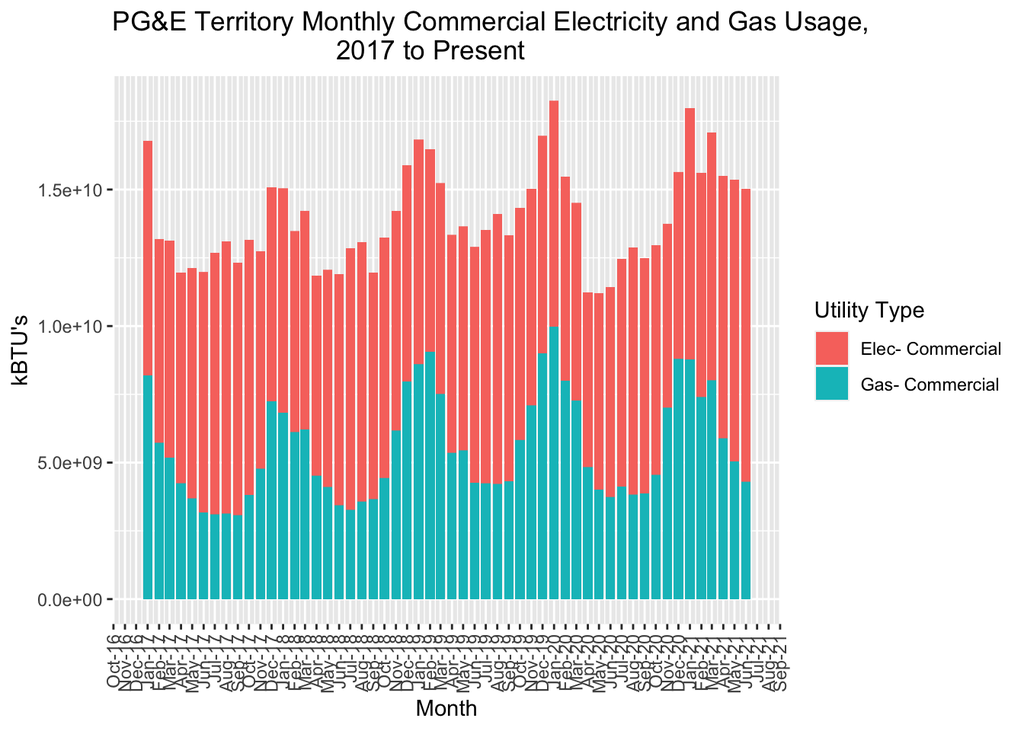

Firstly, it should be noted that in 2017 there was an outlier removed: the commerical data included the month of September in both the Q3 and Q4 files. This duplicate data was removed in order to ensure the plots are consistent with the actual utility usage.

There are noticable differences between the Commerical utility use, notably electricity, during the COVID pandemic. In April 2020, a sharp decrease in commerical electricity use can be seen on the above chart. These trend can be seen in more detail below, where only 2019 and 2020 are plotted:

[figure not shown]

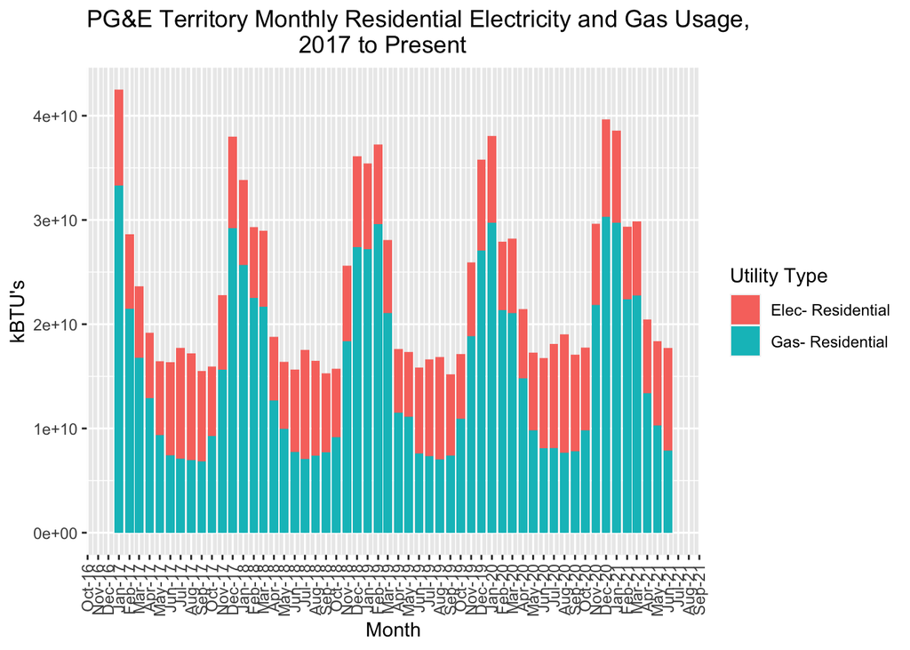

In terms of residential electricity and gas use across the four analysis years, there was a slight increase as a result of the pandemic. This is reasonable as there were more people working and spending extra time at home.

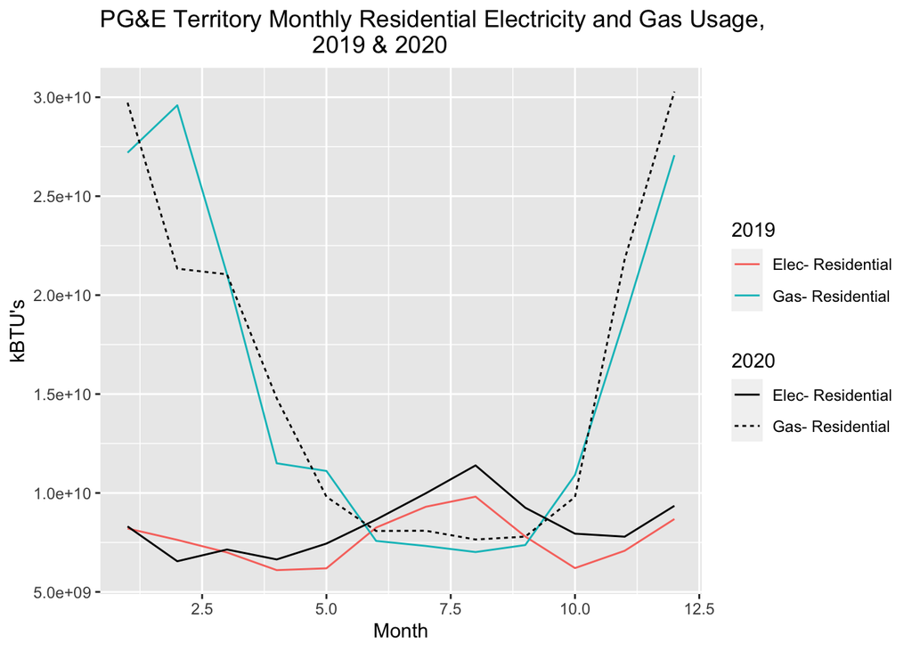

The above plot represents residential gas and electricity trends for only 2019 and 2020. As expected, there was a marginal increase in residential electricity and gas use as a result of the pandemic (beginning in April 2020). This follows the logical trend, as many people spent more time at home (ie. working). Line charts were used to more closely show the trends for the direct comparisons as a result of the pandemic.

Key assumptions: It is assumed that the given CSV files obtained from the Pacific Gas and Electricity Company are accurate and representative of the actual trends. Also, since the values are averages, it doesn’t take into account individual nuances within zipcodes. Further analysis should be completed within specific zipcodes to gain a better idea of local trends.